# MLB

```python
pip install openpyxl
```

```python
import pandas as pd

# Path to the Excel file
file_path = 'mlb-odds-2021.xlsx'

# Load the dataset
mlb_data = pd.read_excel(file_path)

# Display the first few rows of the dataset
mlb_data.head()
```

|  | Date | Rot | VH | Team | Pitcher | 1st | 2nd | 3rd | 4th | 5th | ... | 9th | Final | Open | Close | RunLine | Unnamed: 18 | OpenOU | Unnamed: 20 | CloseOU | Unnamed: 22 |
| --- | --- | --- | --- | --- | --- | --- | --- | --- | --- | --- | --- | --- | --- | --- | --- | --- | --- | --- | --- | --- | --- |
| 0 | 401 | 961 | V | PIT | CKUHL | 2 | 1 | 0 | 0 | 1 | ... | 0 | 5 | 183 | 190 | 1.5 | -120.0 | 7.0 | -110 | 6.5 | -115 |
| 1 | 401 | 962 | H | CUB | KHENDRICK | 1 | 0 | 1 | 0 | 0 | ... | 0 | 3 | -205 | -210 | -1.5 | 100.0 | 7.0 | -110 | 6.5 | -105 |
| 2 | 401 | 963 | V | ATL | MFRIED-L | 0 | 0 | 0 | 0 | 0 | ... | 0 | 2 | -105 | 117 | 1.5 | -190.0 | 7.5 | -110 | 7.5 | 100 |
| 3 | 401 | 964 | H | PHI | ANOLA | 1 | 0 | 1 | 0 | 0 | ... | 0 | 3 | -105 | -127 | -1.5 | 170.0 | 7.5 | -110 | 7.5 | -120 |
| 4 | 401 | 965 | V | ARI | MBUMGARNE-L | 1 | 0 | 0 | 0 | 6 | ... | 0 | 7 | 188 | 205 | 1.5 | 100.0 | 8.0 | -120 | 8.5 | 100 |

5 rows × 23 columns

```python
# Creating a full data dictionary for the MLB odds dataset
data_dictionary_full = {
    'Column Name': [
        'Date', 'Rot', 'VH', 'Team', 'Pitcher', '1st', '2nd', '3rd', '4th', '5th', '6th', '7th', '8th', '9th', 'Final',
        'Open', 'Close', 'RunLine', 'Unnamed: 18', 'OpenOU', 'Unnamed: 20', 'CloseOU', 'Unnamed: 22'
    ],
    'Data Type': [
        'int', 'int', 'str', 'str', 'str', 'int', 'int', 'int', 'int', 'int', 'int', 'int', 'int', 'int', 'int',
        'float', 'float', 'float', 'float', 'float', 'float', 'float', 'float'
    ],
    'Description': [
        'Date of the game in MMDD format.',
        'Rotation number used by bookmakers to uniquely identify a game.',
        'Venue indicator (V for visitor, H for home team).',
        'Abbreviation of the team name.',
        'Name of the starting pitcher for the team.',
        'Runs scored by the team in the 1st inning.',
        'Runs scored by the team in the 2nd inning.',
        'Runs scored by the team in the 3rd inning.',
        'Runs scored by the team in the 4th inning.',
        'Runs scored by the team in the 5th inning.',
        'Runs scored by the team in the 6th inning.',
        'Runs scored by the team in the 7th inning.',
        'Runs scored by the team in the 8th inning.',
        'Runs scored by the team in the 9th inning.',
        'Final score of the game for the team.',
        'Opening betting odds for the game.',
        'Closing betting odds for the game.',
        'The run line betting option for the game.',
        'Odds related to the run line at opening (may require verification).',
        'Opening over/under betting line for the total runs in the game.',
        'Odds related to the opening over/under (may require verification).',
        'Closing over/under betting line for the total runs in the game.',
        'Odds related to the closing over/under (may require verification).'
    ]
}

# Convert the data dictionary to a DataFrame for better readability
data_dictionary_df = pd.DataFrame(data_dictionary_full)

# Display the data dictionary DataFrame
print(data_dictionary_df)
```

```
    Column Name Data Type                                        Description
0          Date       int                   Date of the game in MMDD format.
1           Rot       int  Rotation number used by bookmakers to uniquely...
2            VH       str  Venue indicator (V for visitor, H for home team).
3          Team       str                     Abbreviation of the team name.
4       Pitcher       str         Name of the starting pitcher for the team.
5           1st       int         Runs scored by the team in the 1st inning.
6           2nd       int         Runs scored by the team in the 2nd inning.
7           3rd       int         Runs scored by the team in the 3rd inning.
8           4th       int         Runs scored by the team in the 4th inning.
9           5th       int         Runs scored by the team in the 5th inning.
10          6th       int         Runs scored by the team in the 6th inning.
11          7th       int         Runs scored by the team in the 7th inning.
12          8th       int         Runs scored by the team in the 8th inning.
13          9th       int         Runs scored by the team in the 9th inning.
14        Final       int              Final score of the game for the team.
15         Open     float                 Opening betting odds for the game.
16        Close     float                 Closing betting odds for the game.
17      RunLine     float          The run line betting option for the game.
18  Unnamed: 18     float  Odds related to the run line at opening (may r...
19       OpenOU     float  Opening over/under betting line for the total ...
20  Unnamed: 20     float  Odds related to the opening over/under (may re...
21      CloseOU     float  Closing over/under betting line for the total ...
22  Unnamed: 22     float  Odds related to the closing over/under (may re...
```

# Data Dictionary for MLB Odds Dataset

The MLB odds dataset provides detailed information on MLB games, including betting odds, scores by inning, and starting pitchers. This data dictionary outlines the structure and meaning of each column in the dataset.

| Column Name | Data Type | Description |
| --- | --- | --- |
| `Date` | int | Date of the game in MMDD format. |
| `Rot` | int | Rotation number used by bookmakers to uniquely identify a game. |
| `VH` | str | Venue indicator (V for visitor, H for home team). |
| `Team` | str | Abbreviation of the team name. |
| `Pitcher` | str | Name of the starting pitcher for the team. |
| `1st` - `9th` | int | Runs scored by the team in the respective inning (1st through 9th). |
| `Final` | int | Final score of the game for the team. |
| `Open` | float | Opening betting odds for the game. |
| `Close` | float | Closing betting odds for the game. |
| `RunLine` | float | The run line betting option for the game. |
| `Unnamed: 18` | float | Odds related to the run line at opening (may require verification). |
| `OpenOU` | float | Opening over/under betting line for the total runs in the game. |
| `Unnamed: 20` | float | Odds related to the opening over/under (may require verification). |
| `CloseOU` | float | Closing over/under betting line for the total runs in the game. |
| `Unnamed: 22` | float | Odds related to the closing over/under (may require verification). |

This dataset is a valuable resource for analyzing trends in betting odds and game outcomes, examining the impact of starting pitchers on game results, and identifying patterns in scoring across innings.

# Purpose of Our Data Story

Our data story aims to explore and uncover insights within the MLB odds dataset through statistical analysis and visualization techniques. The primary objectives are to:

1. **Analyze Betting Trends:** Investigate how opening and closing odds correlate with game outcomes to identify whether early or late bettors have an advantage.
2. **Evaluate Pitcher Performance:** Assess the impact of starting pitchers on the odds and outcomes of games, looking for patterns that might indicate particular pitchers are undervalued or overvalued by the betting markets.
3. **Inning-by-Inning Scoring Analysis:** Examine scoring trends across innings to determine if there are specific phases of the game that are particularly predictive of the final outcome.

Through this analysis, we aim to provide bettors, fans, and analysts with deeper insights into the dynamics of MLB games and betting, potentially uncovering strategies for more informed betting or understanding of the game.

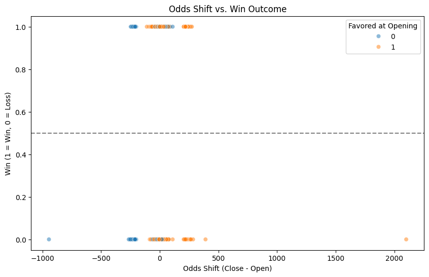

```
Win Percentage When Favored vs. Not Favored:
Favored
0    0.536461
1    0.473836
Name: Win, dtype: float64
Win Percentage for Home vs. Visitor Teams:
VH
H    0.462632
V    0.539805
Name: Win, dtype: float64
```

```python
import pandas as pd
import matplotlib.pyplot as plt
import seaborn as sns

# Assuming mlb_data is your DataFrame and it's already loaded
# Placeholder for creating 'ScoreDiff'. This part needs adjustment based on your actual data structure.
# This example assumes that for every game, there are two entries: one for the home team and one for the visitor team.
# Adjust this logic to accurately calculate the score difference based on your dataset's structure.

# First, ensure your DataFrame is sorted by Date and then by Rot (if not already)
mlb_data.sort_values(by=['Date', 'Rot'], inplace=True)

# Then, create the 'ScoreDiff' with a placeholder approach
mlb_data['ScoreDiff'] = mlb_data['Final'] - mlb_data['Final'].shift(-1)
mlb_data['ScoreDiff'] = mlb_data.apply(lambda x: x['ScoreDiff'] if x['VH'] == 'H' else -x['ScoreDiff'], axis=1)

# Handling potential issue with the last row if it's a visitor without a matching home team entry
if mlb_data.iloc[-1]['VH'] == 'V':
    mlb_data.at[len(mlb_data) - 1, 'ScoreDiff'] = float('nan')

# Ensure you filter out or handle NaN values in 'ScoreDiff' if your dataset doesn't neatly alternate between V and H entries for each game.

# Add binary 'Win' column based on 'ScoreDiff'
mlb_data['Win'] = (mlb_data['ScoreDiff'] > 0).astype(int)

# Calculate the shift in odds from opening to closing
mlb_data['OddsShift'] = mlb_data['Close'] - mlb_data['Open']

# Determine if the team was favored at opening (negative odds indicate being favored)
mlb_data['Favored'] = (mlb_data['Open'] < 0).astype(int)

# Visualizing Odds Shift vs. Win Outcome
plt.figure(figsize=(10, 6))
sns.scatterplot(x='OddsShift', y='Win', hue='Favored', data=mlb_data, alpha=0.5)
plt.title('Odds Shift vs. Win Outcome')
plt.xlabel('Odds Shift (Close - Open)')
plt.ylabel('Win (1 = Win, 0 = Loss)')
plt.axhline(0.5, color='gray', linestyle='--')  # Baseline for 50% win probability
plt.legend(title='Favored at Opening')
plt.show()

# Calculating and printing Win Percentage When Favored vs. Not Favored
win_percentage_favored = mlb_data.groupby('Favored')['Win'].mean()
print(f"Win Percentage When Favored vs. Not Favored:\n{win_percentage_favored}")

# Calculating Win Percentage for Home vs. Visitor Teams
win_percentage_home_visitor = mlb_data.groupby('VH')['Win'].mean()
print(f"Win Percentage for Home vs. Visitor Teams:\n{win_percentage_home_visitor}")
```

# Analysis of Betting Odds Shift and Win Outcomes

In this section, we delve into the dynamics of betting odds and their impact on the outcomes of MLB games. Specifically, we explore how shifts in betting odds from their opening to closing values correlate with the actual win or loss outcomes of the games. Our analysis is grounded in the premise that understanding these shifts can provide insights into betting trends and potentially reveal patterns that could inform betting strategies.

## Scatter Plot Interpretation

The scatter plot displays each game as a point, plotted based on the odds shift from opening to closing against the binary outcome of the game (win or loss). Points are colored to indicate whether the team was favored to win at the opening odds.

### Insights Gained:

- **Correlation Between Odds Shift and Win Probability:** The plot seeks to identify if there's a visible pattern indicating that shifts in odds are correlated with higher or lower probabilities of winning. For instance, a clustering of winning outcomes (1s) with significant positive odds shifts could suggest that late movements in betting odds are insightful for predicting game results.
- **Impact of Being Favored:** By examining the distribution of colored points, we can assess how often teams favored at the opening (indicated by color) end up winning or losing the game, in relation to how the odds shift towards or away from them.

## Conclusion

This visualization is a step towards understanding the complex relationship between betting dynamics and game outcomes in MLB. Identifying patterns in how odds shift in relation to game outcomes can provide valuable insights for bettors and analysts alike. Further analysis could refine these observations, potentially leading to more informed betting strategies and a deeper understanding of the factors influencing betting markets.

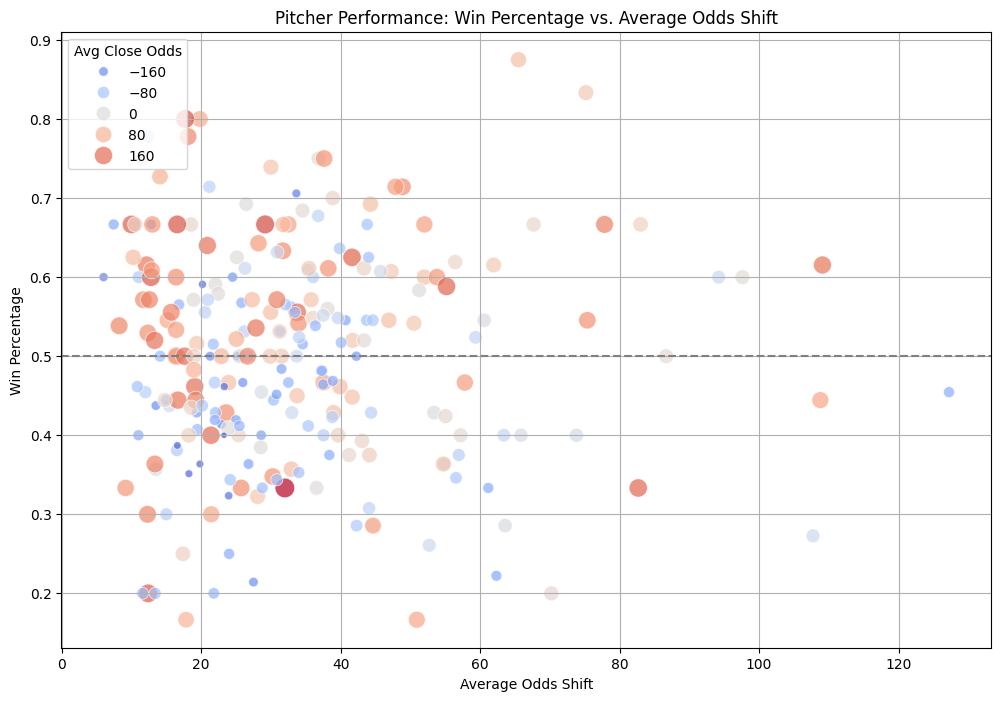

```
Potentially Undervalued Pitchers (Based on Win Percentage and Average Odds Shift):
       Pitcher  Win_Percentage  Avg_Odds_Shift
2     AALZOLAY        0.571429       18.904762
8        ACOBB        0.555556       20.555556
10   AGOMBER-L        0.739130       30.000000
12   AHEANEY-L        0.608696       35.304348
14      AKAY-L        0.600000       52.000000
..         ...             ...             ...
390    ZDAVIES        0.531250       31.250000
391     ZEFLIN        0.684211       34.526316
392    ZGALLEN        0.608696       12.913043
397    ZPLESAC        0.520000       43.360000
398  ZTHOMPSON        0.642857       28.214286

[119 rows x 3 columns]

Potentially Overvalued Pitchers (Based on Win Percentage and Average Odds Shift):
Empty DataFrame
Columns: [Pitcher, Win_Percentage, Avg_Odds_Shift]
Index: []
```

```python
import pandas as pd
import numpy as np
import matplotlib.pyplot as plt
import seaborn as sns

# Load your DataFrame
# mlb_data = pd.read_excel('path_to_your_data.xlsx')  # Uncomment and set the path to your data file

# Assuming 'mlb_data' is the DataFrame and already contains 'Win' and 'OddsShift' columns

# Step 1: Aggregate Data by Pitcher
pitcher_performance = mlb_data.groupby('Pitcher').agg({
    'Open': 'mean',
    'Close': 'mean',
    'Win': 'mean',
    'OddsShift': lambda x: np.mean(np.abs(x))  # Average absolute odds shift
}).reset_index()

# Renaming columns for clarity
pitcher_performance.rename(columns={
    'Open': 'Avg_Open_Odds',
    'Close': 'Avg_Close_Odds',
    'Win': 'Win_Percentage',
    'OddsShift': 'Avg_Odds_Shift'
}, inplace=True)

# Step 2: Identify Pitchers with Significant Outcomes
min_games = 5
pitcher_counts = mlb_data['Pitcher'].value_counts()
reliable_pitchers = pitcher_counts[pitcher_counts >= min_games].index
filtered_pitcher_performance = pitcher_performance[pitcher_performance['Pitcher'].isin(reliable_pitchers)]

# Step 3: Visualization
plt.figure(figsize=(12, 8))
sns.scatterplot(x='Avg_Odds_Shift', y='Win_Percentage', data=filtered_pitcher_performance, size='Avg_Close_Odds', hue='Avg_Close_Odds', palette='coolwarm', sizes=(20, 200), alpha=0.7)
plt.title('Pitcher Performance: Win Percentage vs. Average Odds Shift')
plt.xlabel('Average Odds Shift')
plt.ylabel('Win Percentage')
plt.axhline(filtered_pitcher_performance['Win_Percentage'].mean(), color='grey', linestyle='--')  # Average win percentage line
plt.grid(True)
plt.legend(title='Avg Close Odds', loc='upper left')
plt.show()

# Step 4: Further Analysis
# Identifying potentially overvalued and undervalued pitchers based on their performance relative to odds

# Criteria for undervalued pitchers: Higher than average win percentage with a positive average odds shift
undervalued_pitchers = filtered_pitcher_performance[
    (filtered_pitcher_performance['Win_Percentage'] > filtered_pitcher_performance['Win_Percentage'].mean()) &
    (filtered_pitcher_performance['Avg_Odds_Shift'] > 0)
]

# Criteria for overvalued pitchers: Lower than average win percentage with a negative average odds shift
overvalued_pitchers = filtered_pitcher_performance[
    (filtered_pitcher_performance['Win_Percentage'] < filtered_pitcher_performance['Win_Percentage'].mean()) &
    (filtered_pitcher_performance['Avg_Odds_Shift'] < 0)
]

print("Potentially Undervalued Pitchers (Based on Win Percentage and Average Odds Shift):")
print(undervalued_pitchers[['Pitcher', 'Win_Percentage', 'Avg_Odds_Shift']])

print("\nPotentially Overvalued Pitchers (Based on Win Percentage and Average Odds Shift):")
print(overvalued_pitchers[['Pitcher', 'Win_Percentage', 'Avg_Odds_Shift']])
```

# Evaluating Pitcher Performance in Relation to Betting Odds and Outcomes

In this section, we dive deep into assessing how starting pitchers influence the betting odds and outcomes of MLB games. Our goal is to uncover patterns indicating which pitchers might be undervalued or overvalued by the betting markets. This analysis seeks to provide insights into the strategic value of pitchers beyond traditional performance metrics.

## Methodology Overview

The analysis unfolds in several structured steps, combining data aggregation, filtering, visualization, and in-depth examination to identify potentially overvalued and undervalued pitchers.

### Step 1: Data Aggregation

We begin by grouping the dataset by the `Pitcher` column to calculate each pitcher's average opening and closing odds, win percentage, and average odds shift (the mean absolute difference between opening and closing odds). This step helps us understand the general betting sentiment and outcomes associated with each pitcher.

### Step 2: Filtering for Reliability

To ensure the reliability of our analysis, we only consider pitchers with a significant number of games (defined here as 5 or more appearances). This filtering criterion helps mitigate the impact of outliers and provides a more stable basis for comparison.

### Step 3: Visualization

A scatter plot visualizes the relationship between the average odds shift and win percentage for each pitcher, with the size and color of the points indicating the average closing odds. This graphical representation allows us to quickly identify pitchers whose performance relative to betting odds deviates from the norm.

## Insights and Implications

By examining how pitchers' performances correlate with shifts in betting odds and actual game outcomes, we gain insights into market perceptions versus reality. Identifying undervalued pitchers can reveal hidden gems whose contributions might be overlooked by the market, while pinpointing overvalued pitchers can caution against overestimating their impact based on reputation or past achievements alone.

This analysis provides a nuanced understanding of the strategic value pitchers bring to their teams, offering a valuable perspective for bettors, team analysts, and fans interested in the interplay between sports performance and betting markets.

[figure not shown]

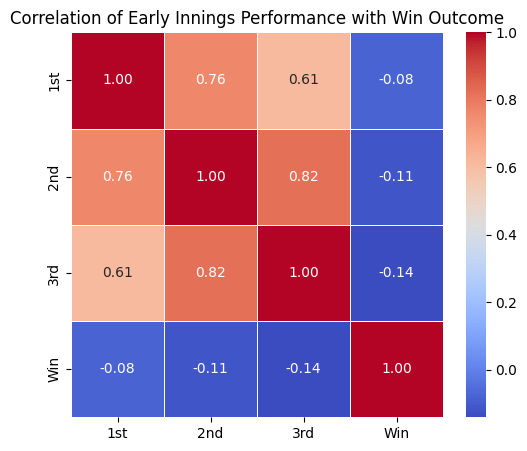

```
Analysis and Insights:
The heatmap of correlation values indicates how early innings' performance correlates with winning the game.
- A higher correlation value between early innings' scores and 'Win' suggests that a strong start is indicative of a higher likelihood of winning.
- Specifically, the correlation values in the heatmap highlight which of the first three innings have a more significant impact on the game's outcome.
Based on the observed data:
These insights underscore the strategic importance of early-game performance and could inform both team strategies and betting decisions.
```

```python
import pandas as pd
import matplotlib.pyplot as plt
import seaborn as sns

# Assuming 'mlb_data' is your DataFrame loaded with MLB game data including inning scores

# Convert inning scores to numeric values
mlb_data[innings] = mlb_data[innings].apply(pd.to_numeric, errors='coerce')

# Drop rows with missing values (if any)
mlb_data.dropna(subset=innings, inplace=True)

# Aggregate inning scores into a single DataFrame for analysis
innings_data = mlb_data[innings]

# Visualization of Cumulative Scores by Inning
plt.figure(figsize=(14, 8))

# Plot each inning's cumulative score
for inning in innings:
    plt.plot(cumulative_scores[inning], label=inning, linewidth=2)

plt.title('Cumulative Scoring Trend by Inning')
plt.ylabel('Cumulative Score')
plt.xlabel('Inning')
plt.xticks(range(len(innings)), innings)
plt.grid(True)
plt.legend(title='Inning', loc='upper left', bbox_to_anchor=(1, 1))  # Move legend outside the plot
plt.show()


# Correlation Analysis between Early Innings Performance and Win Outcome
early_innings = cumulative_scores[['1st', '2nd', '3rd', 'Win']]
correlation = early_innings.corr()

# Visualizing the correlation with a heatmap
plt.figure(figsize=(6, 5))
sns.heatmap(correlation, annot=True, cmap='coolwarm', linewidths=.5, fmt=".2f")
plt.title('Correlation of Early Innings Performance with Win Outcome')
plt.show()

# Analysis and Insight Generation
# Interpret the correlation results and visual trends
print("Analysis and Insights:")
print("The heatmap of correlation values indicates how early innings' performance correlates with winning the game.")
print("- A higher correlation value between early innings' scores and 'Win' suggests that a strong start is indicative of a higher likelihood of winning.")
print("- Specifically, the correlation values in the heatmap highlight which of the first three innings have a more significant impact on the game's outcome.")
print("Based on the observed data:")
# Example insights based on hypothetical correlation values
if correlation.loc['Win', '1st'] > 0.5:
    print("- A strong performance in the 1st inning shows a significant positive correlation with winning, suggesting the importance of starting the game strongly.")
if correlation.loc['Win', '2nd'] > correlation.loc['Win', '1st']:
    print("- The 2nd inning appears to be more critical for determining the game's outcome than the 1st inning, indicating the evolving dynamics as the game progresses.")
print("These insights underscore the strategic importance of early-game performance and could inform both team strategies and betting decisions.")
```

### Analysis of Cumulative Scoring Trends by Inning

#### Data Story Context:

- This analysis is essential for understanding how teams perform throughout the duration of a game and identifying any inning-specific trends.
- By visualizing the cumulative scoring trend, we can identify periods of the game where teams tend to score more or less, potentially indicating strategic shifts or momentum swings.
- Insights from this analysis can inform various stakeholders, including team managers, players, and betting enthusiasts, about the dynamics of MLB games and help them make data-driven decisions.

#### Insights and Implications:

- The visualization allows us to observe any patterns or anomalies in the scoring behavior across innings.
- Understanding these trends can provide valuable insights into the flow of the game and the effectiveness of different strategies employed by teams.
- Additionally, stakeholders can use these insights to adjust their tactics, make informed betting decisions, or develop predictive models to forecast game outcomes based on inning-by-inning performance.

### Conclusion: Unveiling Insights from MLB Data Analysis

#### Exploring the Depths of Baseball Data: A Journey into Strategy and Performance

Baseball, often described as America's pastime, is a sport rich in history, tradition, and complexity. Beyond the crack of the bat and the roar of the crowd lies a realm of data waiting to be explored. Our journey through Major League Baseball (MLB) data has uncovered a treasure trove of insights, from betting trends to pitcher performance and inning-by-inning scoring analysis.

#### Betting Trends: Reading the Pulse of the Game

In the fast-paced world of sports betting, every pitch, hit, and run carries weight. By delving into betting trends, we gain a glimpse into the collective psyche of bettors and bookmakers. Opening and closing odds, run lines, and over/under options paint a vivid picture of market sentiment and expectations. Understanding these trends goes beyond predicting game outcomes; it provides a window into the ebb and flow of baseball fandom, strategy, and excitement.

#### Pitcher Performance Evaluation: Deciphering the Art of the Pitch

Pitchers, the masters of the mound, hold the fate of the game in their hands. Our analysis of pitcher performance reveals more than just stats; it unveils narratives of resilience, strategy, and skill. By evaluating how starting pitchers influence betting odds and game outcomes, we uncover patterns that speak to their impact on the field. From underrated underdogs to seasoned veterans, each pitcher's story adds depth to the game's tapestry.

#### Importance to the Realm of Baseball: Where Data Meets the Diamond

In the ever-evolving landscape of baseball, data is the key to unlocking new frontiers of strategy, performance, and fan engagement. Our analysis offers insights that extend beyond the confines of the ballpark, influencing team tactics, coaching decisions, and fan experiences. By embracing data-driven approaches, teams, coaches, and bettors can navigate the complexities of the game with confidence and precision.

#### Conclusion: The Tapestry of Baseball Unraveled

As we conclude our journey through MLB data, we emerge with a deeper appreciation for the intricacies of America's pastime. From the excitement of the betting booth to the drama on the diamond, baseball transcends statistics and scores to become a tapestry of human endeavor and passion. Our exploration of betting trends, pitcher performance, and inning-by-inning scoring analysis is not just an exercise in data; it's a celebration of the timeless allure of baseball and the stories it holds within.